# Análisis de los factores que influyen en la desigualdad de género a nivel mundial

Curso: POL304 - Estadística para el análisis político 2

Alessandra Marocho, Mayeli Charra, Melany Rodríguez

Noviembre, 2022

# Introducción

La siguiente investigación tiene como propósito analizar los factores que pueden influir en la desigualdad de género a nivel mundial. Para evaluar ello, empleamos el índice de desigualdad de género - Gender Inequality Index (GII), elaborado por Human Development Reports. La presente base de datos se encuentra distribuida en tres dimensiones: salud, empoderamiento y mercado laboral. Además, algunos de los indicadores que lo componen son datos a nivel mundial sobre ratio de mortalidad maternal, tasa de embarazo adolescente, población de femenina y masculina con al menos educación secundaria, entre otros.

Se sostiene que, en función de este trabajo, existen factores sociales, políticos, económicos y militares que influyen en nuestra variable dependiente. En primer lugar, el factor político se representará a través de un índice de democracia, un índice de percepción de la corrupción y un índice de derechos civiles. Con respecto a los factores económicos, se articularán por medio del coeficiente GINI y un índice de crecimiento económico. También se usarán el índice de desarrollo humano, el porcentaje de población urbana y el porcentaje de no religiosos para los factores sociales. Finalmente, el factor militar estará compuesto de un índice de militarización global.

# 1. Análisis rápido de la data

A nivel mundial, la desigualdad de género en promedio es igual a 40.7%. El porcentaje de desigualdad de género por país durante el año 2021 se puede observar en la siguiente tabla:

|  | country | Desigualdad de género |
| --- | --- | --- |
| 1 | Angola | 53.7 |
| 2 | Albania | 14.4 |
| 3 | Argentina | 28.7 |
| 4 | Armenia | 21.6 |
| 5 | Azerbaijan | 29.4 |
| 6 | Burundi | 50.5 |
| 7 | Benin | 60.2 |
| 8 | Burkina Faso | 62.1 |
| 9 | Bangladesh | 53 |
| 10 | Bulgaria | 21 |

[output cut: 90 more lines]

De igual manera, el siguiente gráfico ilustra los resultados del índice de desigualdad de género a nivel mundial, visibilizando desde las zonas geográficas menos a más desiguales en cuestiones de género:

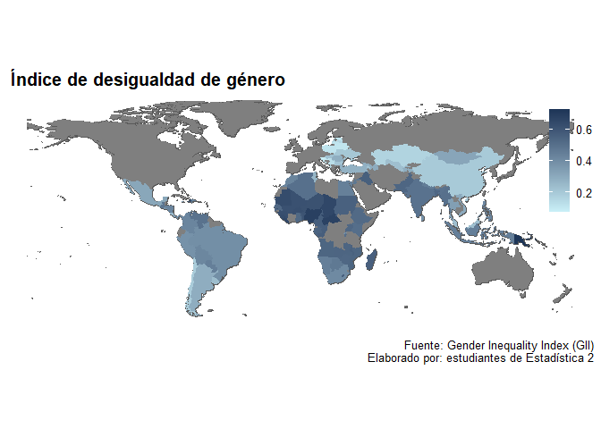

# 2. Modelación

En esta sección, se realizarán regresiones lineales simples y múltiples con las variables independientes seleccionadas.

## Regresión Alessandra

### Regresiones lineales simples

**Regresión lineal (género y IDH)**

Regresion Lineal 1

|  | mnodelo1 |
| --- | --- |
| (Intercept) | 1.092*** |
|  | (0.043) |
| IDH | −1.034*** |
|  | (0.064) |
| Num.Obs. | 100 |
| R2 | 0.728 |
| R2 Adj. | 0.726 |
| AIC | −198.7 |
| BIC | −190.9 |
| Log.Lik. | 102.371 |
| F | 262.674 |
| RMSE | 0.09 |

+ p < 0.1, * p < 0.05, ** p < 0.01, *** p < 0.001

En primer lugar, al observar el p - value, podemos determinar que el modelo el válido. Asimismo, el modelo tiene una predictibilidad de 72.8%, determinada por el R2. Además, el índice de desarrollo humano (IDH) es una variable que aporta al modelo. Al ser inversa, significa que, ante un incremento en el IDH, se observa una disminución en la desigualdad de género.

**Regresión simple (género y GINI)**

Regresion Lineal 2

|  | modelo2 |
| --- | --- |
| (Intercept) | 0.135+ |
|  | (0.081) |
| gini | 0.691*** |
|  | (0.201) |
| Num.Obs. | 100 |
| R2 | 0.108 |
| R2 Adj. | 0.098 |
| AIC | −79.8 |
| BIC | −72.0 |
| Log.Lik. | 42.909 |
| F | 11.807 |
| RMSE | 0.16 |

+ p < 0.1, * p < 0.05, ** p < 0.01, *** p < 0.001

Podemos afirmar que el modelo es válido, puesto que el p - value es menor 0.05. Posteriormente, de acuerdo con el R2, la predictibilidad del modelo sería del 10%, un valor bastante reducido. Igualmente, el coeficiente de gini aporta al modelo porque su p - value es menor a 0.05. Por consiguiente, se puede afirmar medianamente que un incremento en la desigualdad de ingresos tiene el mismo efecto sobre la desigualdad de género.

**Regresión simple (género y derechos civiles)**

Regresion Lineal 3

|  | modelo3 |
| --- | --- |
| (Intercept) | 0.587*** |
|  | (0.040) |
| civil | −0.035*** |
|  | (0.007) |
| Num.Obs. | 100 |
| R2 | 0.194 |
| R2 Adj. | 0.186 |
| AIC | −90.0 |
| BIC | −82.2 |
| Log.Lik. | 48.000 |
| F | 23.578 |
| RMSE | 0.15 |

+ p < 0.1, * p < 0.05, ** p < 0.01, *** p < 0.001

Finalmente, con respecto al modelo 3 podemos afirmar que es válido, puesto que tiene un p - value menor a 0.05. Con respecto a su predictibilidad, de acuerdo con el R2, es de 19.4%. Igualmente, podemos afirmar que nuestra variable independiente aporta al modelo al tener un p - value menor a 0.05. Por medio del presente modelo podemos indicar que, ante un incremento en el índice de derechos civiles, el efecto sobre el índice de la desigualdad de género será inverso.

### Regresión lineal múltiple

Regresión Lineal 4

|  | modelo 4 |
| --- | --- |
| (Intercept) | 0.928*** |
|  | (0.066) |
| IDH | −0.946*** |
|  | (0.070) |
| gini | 0.354** |
|  | (0.109) |
| civil | −0.007 |
|  | (0.005) |
| Num.Obs. | 100 |
| R2 | 0.758 |
| R2 Adj. | 0.751 |
| AIC | −206.5 |
| BIC | −193.4 |
| Log.Lik. | 108.233 |
| F | 100.421 |
| RMSE | 0.08 |

+ p < 0.1, * p < 0.05, ** p < 0.01, *** p < 0.001

Con respecto a las variables, el p-value de las variables relacionadas con el IDH y el coeficiente de gini es menor a 0.05. En consecuencia, podemos afirmar que ambas aportan a nuestro modelo. No obstante, la variable relacionada con los derechos civiles es mayor, por lo que esta sería no tendría capacidad predictiva.

Es decir, en función de este modelo, el incremento en la desigualdad de ingresos puede elevar la desigualdad de género a nivel mundial, puesto que mantienen una relación directa. De igual manera, el incremento en el índice de desarrollo humano en cada país tiene un efecto inverso; es decir, disminuye la desigualdad de género.

### Supuestos

**Linealidad**

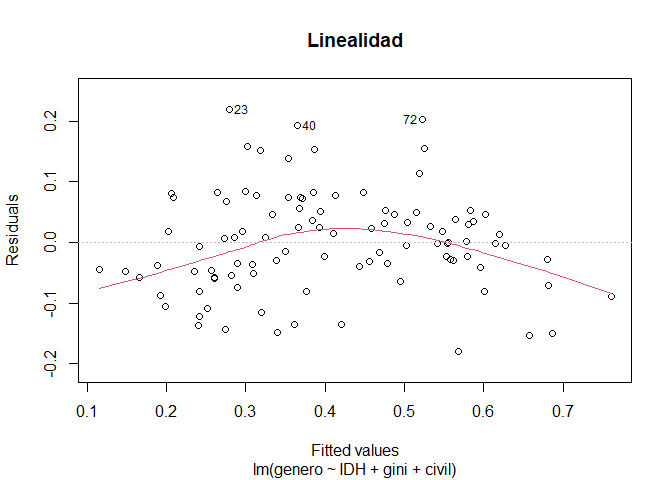

Promedio de residuos:

```
## [1] 3.186741e-18
```

**Normalidad:**

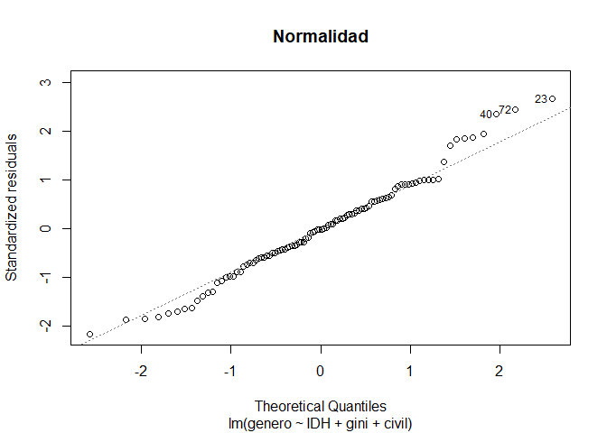

Prueba de Shapiro-Wilk:

Shapiro-Wilk normality test

|  | SW | p.value |
| --- | --- | --- |
| W | 0.9851141 | 0.3236542 |

No obstante, el p-value de la prueba Shapiro-Wilk es igual a 0.324, siendo mayor a 0.05. En consecuencia, podemos afirmar que hay normalidad.

**Homeocedasticidad:**

[figure not shown]

Prueba de Breusch-Pagan:

studentized Breusch-Pagan test

|  | SW | p.value |
| --- | --- | --- |
| BP | 8.739965 | 0.0329556 |

Con respecto a la homocedasticidad, la línea de nuestro modelo no es horizontal y obsevamos que los residuos se encuentran dispersos, por lo que no podemos afirmar completamente que se cumpla el supuesto de homocedasticidad.

No obstante, al emplear la prueba de Breusch-Pagan el resultado obtenido no es mayor a 0.05. Por ello, podemos afirmar que no se cumple con este supuesto.

**Valores influyentes:**

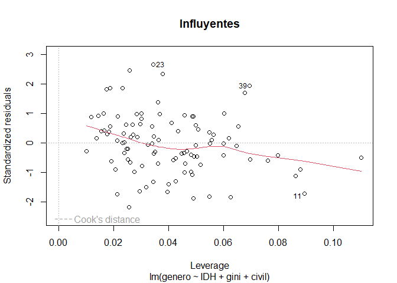

Por medio del gráfico, podemos notar que son reducidos el número de casos que se encuentran por encima de 1.LA mayoría de los casos si siguen el patrón general.

**Multicolinealidad:**

```
##      IDH     gini    civil
## 1.332316 1.054703 1.276770
```

Por medio de la prueba VIF, podemos observar que no hay correlación entre las variables independientes, puesto que todos los valores son menores a 5.

## Regresión Melany

### Regresiones lineales simples

**Regresión índice de democracia**

Hipótesis - A mayor valor en el índice de democracia, menor será la desigualdad de género

[output not shown]

[output not shown]

Regresion Lineal 1

|  | OLS asegurados (I) |
| --- | --- |
| (Intercept) | 0.601*** |
|  | (0.050) |
| demo | −0.037*** |
|  | (0.009) |
| Num.Obs. | 100 |
| R2 | 0.146 |
| R2 Adj. | 0.137 |
| AIC | −84.2 |
| BIC | −76.4 |
| Log.Lik. | 45.099 |
| F | 16.724 |
| RMSE | 0.15 |

+ p < 0.1, * p < 0.05, ** p < 0.01, *** p < 0.001

**INTERPRETACION 1-REGRESION INDEX DEMOCRACY**

En cuanto al modelo, el porcentaje de explicación es de 14.6%, medido a través del R2. El p-valor de la variable index democracy es 8.87e-05, lo cual es menor a 0.05 y evidencia que el modelo es válido. La hipótesis se ve corroborada.

- En otras palabras, mientras mayor sea el índice de democracia, menor serán las probabilidades de que se evidencie desigualdad de género en el país respectivo.

**Regresión crecimiento económico**

Hipótesis - A mayor índice de crecimiento economico, mayor será el índice de desigualdad de género

Regresion Lineal 2

|  | OLS asegurados (I) |
| --- | --- |
| (Intercept) | 0.479*** |
|  | (0.025) |
| Growth | −0.014*** |
|  | (0.004) |
| Num.Obs. | 100 |
| R2 | 0.125 |
| R2 Adj. | 0.116 |
| AIC | −81.8 |
| BIC | −73.9 |
| Log.Lik. | 43.876 |
| F | 13.952 |
| RMSE | 0.16 |

+ p < 0.1, * p < 0.05, ** p < 0.01, *** p < 0.001

**INTERPRETACION 2-REGRESION ECONOMIC GROWTH**

La variable crecimiento económico tiene un efecto significativo evidenciado por los asteriscos (***). El efecto es indirecto debido a que el coeficiente es negativo. Con ello, la hipótesis se ve debatida: a mayor índice de crecimiento económico, menor será el índice de desigualdad de género.

**Regresión porcentaje de no afiliados a religión alguna**

Hipótesis - A mayor porcentaje de inafiliados, menor será el índice de desigualdad de género

Regresion Lineal 3

|  | OLS asegurados (I) |
| --- | --- |
| (Intercept) | 0.451*** |
|  | (0.018) |
| Unaffiliated | −0.629*** |
|  | (0.138) |
| Num.Obs. | 100 |
| R2 | 0.175 |
| R2 Adj. | 0.166 |
| AIC | −87.6 |
| BIC | −79.8 |
| Log.Lik. | 46.810 |
| F | 20.717 |
| RMSE | 0.15 |

+ p < 0.1, * p < 0.05, ** p < 0.01, *** p < 0.001

**INTERPRETACION 3-REGRESION UNAFFILIATED**

En cuanto al modelo, el porcentaje de explicaciones es de 16.6%, medido a través del R2 ajustado. El p-valor de la variable independiente es 1.53e-05, lo cual es menor a 0.05 y evidencia que el modelo es válido.

- En otras palabras, mientras mayor sea el porcentaje de personas no afiliadas a religión alguna, menor serán las probabilidades de que se evidencie desigualdad de género el país respectivo. Por lo que decimos que esta variable impacta significativamente con un 16.6%.

### Regresión lineal múltiple

DEMOCRACIA, CRECIMIENTO Y NO AFILIADOS

Regresion Lineal 4

|  | OLS asegurados (I) |
| --- | --- |
| (Intercept) | 0.606*** |
|  | (0.045) |
| demo | −0.021* |
|  | (0.009) |
| Growth | −0.009** |
|  | (0.004) |
| Unaffiliated | −0.529*** |
|  | (0.130) |
| Num.Obs. | 100 |
| R2 | 0.317 |
| R2 Adj. | 0.295 |
| AIC | −102.5 |
| BIC | −89.5 |
| Log.Lik. | 56.249 |
| F | 14.820 |
| RMSE | 0.14 |

+ p < 0.1, * p < 0.05, ** p < 0.01, *** p < 0.001

### Supuestos

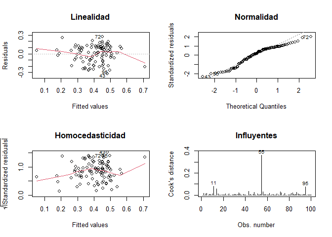

**LINEALIDAD** - Hay linealidad, se espera que estén cercanos a 0 y con una línea horizontal. La línea cuenta con una tendencia horizontal, los datos están concentrados entre valores de 0.3 y 0.5.

```
##
##  studentized Breusch-Pagan test
##
## data:  regresion4
## BP = 0.95979, df = 3, p-value = 0.811
```

**NORMALIDAD DE RESIDUOS** - Los puntos se acercan más a la línea del gráfico, pero el p-valor de la prueba Shapiro-Wilk es menor a 0.05, por lo que no hay normalidad de residuos.

```
##
##  Shapiro-Wilk normality test
##
## data:  regresion4$residuals
## W = 0.94966, p-value = 0.0007875
```

**NO MULTICOLINEALIDAD** - Los valores son menores a 5 por lo que cumple es supuesto.

```
##         demo       Growth Unaffiliated
##     1.195071     1.155015     1.043206
```

## Regresión Mayeli

### Regresiones lineales simples

**Regresión 1: Población Urbana**

Hipótesis - Hay mayor desigualdad de género a menor urbanizacion.

Regresion Lineal 1

|  | GII x Urbanizacion |
| --- | --- |
| (Intercept) | 0.610*** |
|  | (0.044) |
| urban | −0.004*** |
|  | (0.001) |
| Num.Obs. | 100 |
| R2 | 0.196 |
| R2 Adj. | 0.188 |
| AIC | −90.3 |
| BIC | −82.5 |
| Log.Lik. | 48.151 |
| F | 23.944 |
| RMSE | 0.15 |

+ p < 0.1, * p < 0.05, ** p < 0.01, *** p < 0.001

Interpretación:

Esta regresión comprueba la hipótesis de que a cada unidad que aumente la desigualdad de género, disminuye la urbanización en -0.004, además el modelo presenta un p-value menor a 0.05, por lo que el modelo es significativo. También, lo confirman los asteriscos (menos de 0.001%) que tenga efecto. En este modelo la variable urbanización explica un 18.82% la desigualdad de género.

**Indice de Militarización Global (GMI)**

Hipótesis - A mayor Indice de Militarización Global (gmi) , menor será el índice de desigualdad de género (gii).

Regresion Lineal 2

|  | GII x GMI |
| --- | --- |
| (Intercept) | 0.521*** |
|  | (0.040) |
| scoremilitar | −0.001** |
|  | (0.000) |
| Num.Obs. | 100 |
| R2 | 0.090 |
| R2 Adj. | 0.081 |
| AIC | −77.9 |
| BIC | −70.1 |
| Log.Lik. | 41.961 |
| F | 9.747 |
| RMSE | 0.16 |

+ p < 0.1, * p < 0.05, ** p < 0.01, *** p < 0.001

**Percepción de la corrupción**

Hipótesis - Una menor percepción de la corrupción explica la desigualdad de género.

Regresion Lineal 3

|  | GII x Corrupción |
| --- | --- |
| (Intercept) | 0.718*** |
|  | (0.045) |
| corru | −0.008*** |
|  | (0.001) |
| Num.Obs. | 100 |
| R2 | 0.353 |
| R2 Adj. | 0.347 |
| AIC | −112.1 |
| BIC | −104.2 |
| Log.Lik. | 59.029 |
| F | 53.582 |
| RMSE | 0.13 |

+ p < 0.1, * p < 0.05, ** p < 0.01, *** p < 0.001

### Regresión lineal múltiple

Regresion Lineal 4

|  | GII x Urbanización+ GMI+ Corrupcion |
| --- | --- |
| (Intercept) | 0.848*** |
|  | (0.051) |
| urban | −0.002** |
|  | (0.001) |
| scoremilitar | 0.000* |
|  | (0.000) |
| corru | −0.007*** |
|  | (0.001) |
| Num.Obs. | 100 |
| R2 | 0.459 |
| R2 Adj. | 0.442 |
| AIC | −125.9 |
| BIC | −112.8 |
| Log.Lik. | 67.933 |
| F | 27.144 |
| RMSE | 0.12 |

+ p < 0.1, * p < 0.05, ** p < 0.01, *** p < 0.001

Interpretación:

$$VD = 0.848 + (−0.002* urban) +(0*
gmi)+(-0.007*corrupcion)$$

### Supuestos

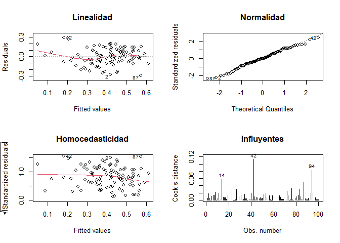

Interpretación:

**Linealidad:** Del último modelo con las tres variables, se asumen una relación lineal, en el caso del modelo la línea roja tiende a ser horizontal y se encuentra cercano a 0. Solo en dos ocasiones la línea se aleja de 0, pero en general se puede asumir linealidad.

**Homocedasticidad:** Se presenta una línea no del todo horizontal, lo que parece ligeramente que las varianzas de los errores de estimación no son constantes en el modelo de regresión. Sin embargo, al realizar la prueba nos da un p-value mayor a 0.05, lo que indica que hay homocedasticidad contradiciendo lo anterior. De manera que sí presenta homocedasticidad.

```
##
##  studentized Breusch-Pagan test
##
## data:  regresion_may
## BP = 4.5505, df = 3, p-value = 0.2078
```

**Normalidad de residuos:** Los puntos de se acercan lo más posible a la línea del gráfico, además el p-value obtenido de la prueba es mayor a 0.05. Lo que nos indica que la distancia entre el valor esperado y el observado se distribuye de manera normal.

```
##
##  Shapiro-Wilk normality test
##
## data:  regresion_may$residuals
## W = 0.98883, p-value = 0.5713
```

```
##        urban scoremilitar        corru
##     1.168707     1.071050     1.107018
```

## Comparación de modelos

```
##
## ==================================================================================================
##                                                       Dependent variable:
##                               --------------------------------------------------------------------
##                                                              genero
##                                        (1)                    (2)                    (3)
## --------------------------------------------------------------------------------------------------
## Constant                             0.928***              0.848***               0.606***
##                                      (0.066)                (0.051)                (0.045)
## IDH                                 -0.946***
##                                      (0.070)
## gini                                 0.354***
##                                      (0.109)
## civil                                 -0.007
##                                      (0.005)
## urban                                                      -0.002***
##                                                             (0.001)
## scoremilitar                                               -0.0004**
##                                                            (0.0002)
## corru                                                      -0.007***
##                                                             (0.001)
## demo                                                                              -0.021**
##                                                                                    (0.009)
## Growth                                                                            -0.009***
##                                                                                    (0.004)
## Unaffiliated                                                                      -0.529***
##                                                                                    (0.130)
## --------------------------------------------------------------------------------------------------
## Observations                           100                    100                    100
## R2                                    0.758                  0.459                  0.317
## Adjusted R2                           0.751                  0.442                  0.295
## Residual Std. Error (df = 96)         0.084                  0.125                  0.141
## F Statistic (df = 3; 96)      100.421*** (p = 0.000) 27.144*** (p = 0.000) 14.820*** (p = 0.00000)
## ==================================================================================================
## Note:                                                                  *p<0.1; **p<0.05; ***p<0.01
```

Y finalmente, el tercer modelo es el que menor porcentaje de explicación tiene para la variable dependiente con un 29.5% de significancia. Las varibles Growth e Unaffiliated son las más significativas para este modelo al presentar 3 asteriscos. Por otro lado, la variable demo es menos significativa que las anteriores al presentar solo 2.

## Regresion lineal múltiple (9 variables)

Regresion Lineal 5

|  | modelo 5 |
| --- | --- |
| (Intercept) | 0.990*** |
|  | (0.066) |
| gini | 0.196+ |
|  | (0.109) |
| IDH | −1.052*** |
|  | (0.093) |
| civil | −0.004 |
|  | (0.007) |
| urban | 0.002*** |
|  | (0.001) |
| scoremilitar | 0.000 |
|  | (0.000) |
| corru | −0.002* |
|  | (0.001) |
| Growth | −0.004* |
|  | (0.002) |
| Unaffiliated | −0.189* |
|  | (0.076) |
| demo | 0.015+ |
|  | (0.008) |
| Num.Obs. | 100 |
| R2 | 0.825 |
| R2 Adj. | 0.808 |
| AIC | −226.8 |
| BIC | −198.2 |
| Log.Lik. | 124.414 |
| F | 47.194 |
| RMSE | 0.07 |

+ p < 0.1, * p < 0.05, ** p < 0.01, *** p < 0.001

El modelo es válido de acuerdo al p - value del F - estadístico, puesto que su p - value es menor a 0.05. De la misma manera, tiene una predictibilidad del 80.7% determinada por el R2 ajustado. Con base en ello, podemos afirmar que el modelo es bastante explicativo. Identificamos que, tanto variables como la de derechos civiles, democracia, militarización y el coeficiente gini no aportan significativamente al modelo, porque sus p - value son mayores a 0.05.

```r
library(lm.beta)
lm.beta::lm.beta(modelo5)
```

```
##
## Call:
## lm(formula = genero ~ gini + IDH + civil + urban + scoremilitar +
##     corru + Growth + Unaffiliated + demo, data = data)
##
## Standardized Coefficients::
##  (Intercept)         gini          IDH        civil        urban scoremilitar
##           NA  0.092964586 -0.867998390 -0.046201181  0.220749827 -0.005732324
##        corru       Growth Unaffiliated         demo
## -0.160484537 -0.112038517 -0.125544098  0.151225901
```

```r
modelo100=list('Efecto'=lm.beta(modelo5))
modelsummary(modelo100, title = "Regresion: modelo 5 con \ncoeficientes estandarizados usando lm.beta()",
             stars = TRUE,
             output = "kableExtra")
```

Regresion: modelo 5 con coeficientes estandarizados usando lm.beta()

|  | Efecto |
| --- | --- |
| gini | 0.093 |
|  | (0.109) |
| IDH | −0.868 |
|  | (0.093) |
| civil | −0.046 |
|  | (0.007) |
| urban | 0.221 |
|  | (0.001) |
| scoremilitar | −0.006 |
|  | (0.000) |
| corru | −0.160 |
|  | (0.001) |
| Growth | −0.112 |
|  | (0.002) |
| Unaffiliated | −0.126 |
|  | (0.076) |
| demo | 0.151 |
|  | (0.008) |
| Num.Obs. | 100 |
| R2 | 0.825 |
| R2 Adj. | 0.808 |
| AIC | −226.8 |
| BIC | −198.2 |
| Log.Lik. | 124.411 |
| RMSE | 0.07 |

+ p < 0.1, * p < 0.05, ** p < 0.01, *** p < 0.001

# 3. Análisis factorial

No se realizará un análisis factorial en este trabajo, puesto que nuestras variables se tratan de índices compuestos anteriormente por otros indicadores. Es decir, las variables latentes que están siendo empleadas ya no aplican para este análisis.

# 4. Análisis de conglomerados

En esta sección, se busca elaborar subconjuntos por medio de las variables dependientes utilizadas:

Creamos otra data únicamente con las variables independientes y reemplazamos el número de las filas por el de los países correspondientes.

A continuación, realizaremos tres estrategias de partición.

## Estrategia de partición

Determinamos el número óptimo de clusters usando el estadístico gap:

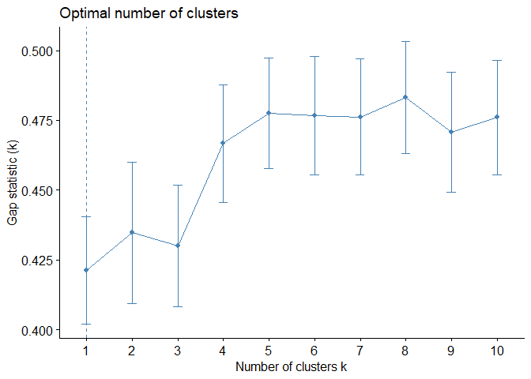

En este caso, a pesar de que el número óptimo es 1, emplearemos 3 clusters para realizar el análisis.

|  | pam |
| --- | --- |
| Angola | 1 |
| Albania | 2 |
| Argentina | 2 |
| Armenia | 3 |
| Azerbaijan | 3 |
| Burundi | 1 |
| Benin | 1 |
| Burkina Faso | 1 |
| Bangladesh | 1 |
| Bulgaria | 2 |
| Belarus | 3 |
| Bolivia | 2 |
| Brazil | 2 |
| Botswana | 2 |
| Central African Republic | 1 |

Observamos las silhouettes:

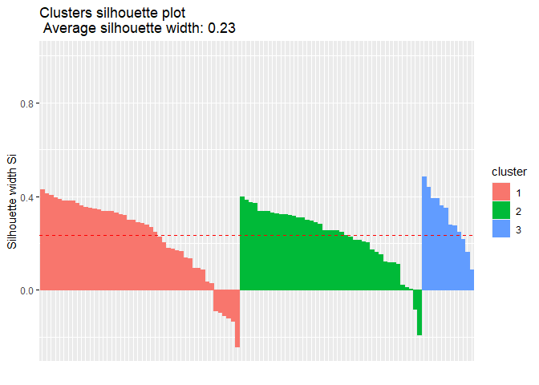

Observamos que la pertenencia de cada caso a los clusters generados en su mayoría es positiva. Sin embargo, se evidencian casos mal clusterizados.

Determinamos los casos mal clusterizados:

```
## [1] "China"      "Congo"      "Egypt"      "Gabon"      "Thailand"
## [6] "Turkey"     "Uzbekistan" "Vietnam"
```

Observamos el orden de las etiquetas:

```
##   pam      corru      urban scoremilitar     Growth       demo Unaffiliated
## 1   1 -0.5488602 -0.6955437   -0.3282059 -0.3083012 -0.5926359  -0.19673330
## 2   2  0.6809443  0.5225710   -0.0910691  0.4198124  0.8937742   0.22833239
## 3   3 -0.2793410  0.8372524    1.5768643 -0.2875223 -0.8564389  -0.04501907
##         gini        IDH      civil
## 1  0.1354746 -0.8783621 -0.5898731
## 2  0.1056777  0.7662306  0.8081871
## 3 -0.8891912  0.6852474 -0.5674746
```

Como no estaban en orden, las reorganizamos y recodificamos.

```
##   pam      corru      urban scoremilitar     Growth       demo Unaffiliated
## 1   1 -0.5488602 -0.6955437   -0.3282059 -0.3083012 -0.5926359  -0.19673330
## 3   3 -0.2793410  0.8372524    1.5768643 -0.2875223 -0.8564389  -0.04501907
## 2   2  0.6809443  0.5225710   -0.0910691  0.4198124  0.8937742   0.22833239
##         gini        IDH      civil
## 1  0.1354746 -0.8783621 -0.5898731
## 3 -0.8891912  0.6852474 -0.5674746
## 2  0.1056777  0.7662306  0.8081871
```

## Estrategia jerárquica

### Estrategia Aglomerativa

Asimismo, por medio de la estrategia aglomerativa evaluamos el esfuerzo por juntar los elementos clusters tras clusters. Para comenzar, definimos el número óptimo de clusters vía agnes:

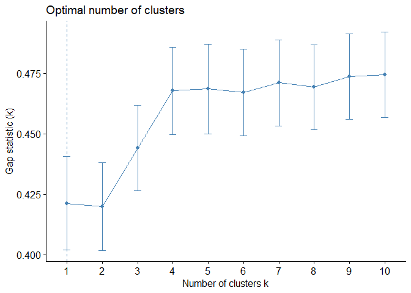

|  | agnes |
| --- | --- |
| Angola | 1 |
| Albania | 2 |
| Argentina | 2 |
| Armenia | 1 |
| Azerbaijan | 1 |
| Burundi | 1 |
| Benin | 3 |
| Burkina Faso | 1 |
| Bangladesh | 1 |
| Bulgaria | 2 |
| Belarus | 1 |
| Bolivia | 3 |
| Brazil | 3 |
| Botswana | 2 |
| Central African Republic | 1 |

El dendograma muestra el proceso de conglomeración AGNES:

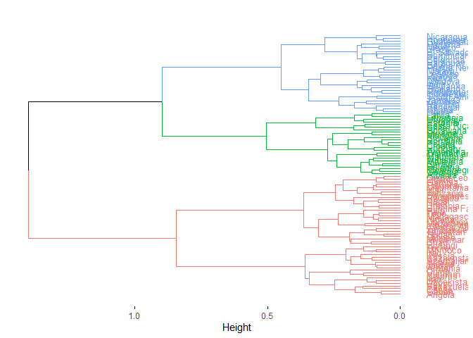

Observamos las siluetas para AGNES:

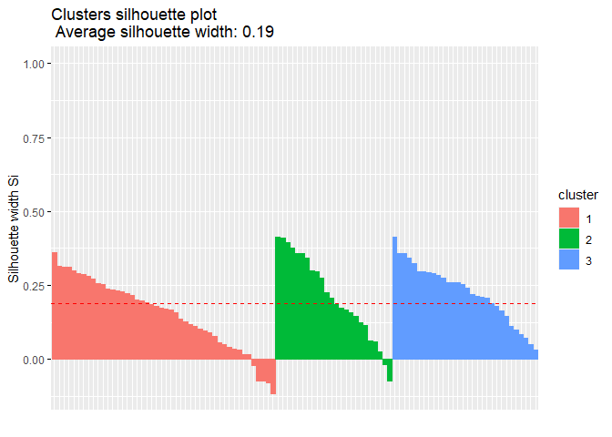

Observamos cuáles fueron los países mal clusterizados:

```
## [1] "Armenia"             "Liberia"             "Madagascar"
## [4] "Malaysia"            "Tanzania"            "Trinidad and Tobago"
## [7] "Turkey"
```

Observamos el promedio de cada clusters:

```
##   agnes      corru      urban scoremilitar     Growth       demo Unaffiliated
## 1     1 -0.4990744 -0.2647849    0.2631274 -0.3930991 -0.9161279   -0.1532005
## 2     2  1.1378624  0.6347876    0.1674797  0.3287351  0.9690086    0.5648636
## 3     3 -0.1450425 -0.1018266   -0.5374458  0.3397639  0.6295226   -0.2169835
##         gini        IDH      civil
## 1 -0.2637141 -0.5250786 -0.7759530
## 2 -0.4387169  1.0491126  1.2554187
## 3  0.7553351 -0.0341696  0.1854596
```

Reordenamos las etiquetas y las recodificamos.

```
##   agnes      corru      urban scoremilitar     Growth       demo Unaffiliated
## 1     1 -0.4990744 -0.2647849    0.2631274 -0.3930991 -0.9161279   -0.1532005
## 3     3 -0.1450425 -0.1018266   -0.5374458  0.3397639  0.6295226   -0.2169835
## 2     2  1.1378624  0.6347876    0.1674797  0.3287351  0.9690086    0.5648636
##         gini        IDH      civil
## 1 -0.2637141 -0.5250786 -0.7759530
## 3  0.7553351 -0.0341696  0.1854596
## 2 -0.4387169  1.0491126  1.2554187
```

### Estrategia Divisiva

Por último, decidimos el número óptimo de clusters por medio de diana:

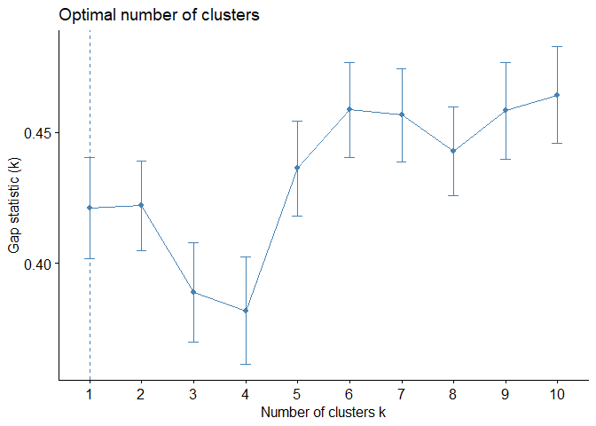

A pesar de que el número óptimo es 1, usaremos 3 clusters:

|  | diana |
| --- | --- |
| Angola | 1 |
| Albania | 2 |
| Argentina | 2 |
| Armenia | 2 |
| Azerbaijan | 1 |
| Burundi | 3 |
| Benin | 2 |
| Burkina Faso | 3 |
| Bangladesh | 3 |
| Bulgaria | 2 |
| Belarus | 1 |
| Bolivia | 2 |
| Brazil | 2 |
| Botswana | 2 |
| Central African Republic | 3 |

Miramos el proceso de conglomeración por medio del dendograma:

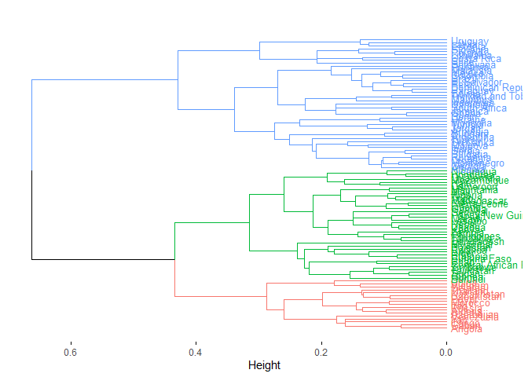

El número de siluetas:

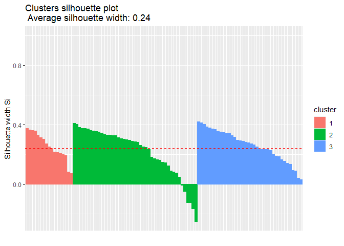

Observamos el número de países mal clusterizados:

```
## [1] "Armenia"   "Benin"     "India"     "Jordan"    "Sri Lanka" "Turkey"
```

Exploramos el promedio de cada cluster:

```
##   diana      corru      urban scoremilitar     Growth       demo Unaffiliated
## 1     1 -0.4593760  0.4982841   1.01835880 -0.3750469 -1.0255370    0.2422927
## 2     2  0.6861951  0.5491349   0.02566118  0.3947143  0.8011047    0.2130524
## 3     3 -0.6070891 -0.8732078  -0.48596981 -0.2996407 -0.4898837   -0.3606929
##          gini        IDH      civil
## 1 -0.45664282  0.4593377 -0.9754111
## 2  0.05312204  0.7173366  0.8247932
## 3  0.14137990 -1.0549707 -0.5403607
```

Reordenamos las etiquetas:

```
##   diana      corru      urban scoremilitar     Growth       demo Unaffiliated
## 3     3 -0.6070891 -0.8732078  -0.48596981 -0.2996407 -0.4898837   -0.3606929
## 1     1 -0.4593760  0.4982841   1.01835880 -0.3750469 -1.0255370    0.2422927
## 2     2  0.6861951  0.5491349   0.02566118  0.3947143  0.8011047    0.2130524
##          gini        IDH      civil
## 3  0.14137990 -1.0549707 -0.5403607
## 1 -0.45664282  0.4593377 -0.9754111
## 2  0.05312204  0.7173366  0.8247932
```

## Visualización comparativa

```r
proyeccion = cmdscale(g.dist, k=2,add = T)
head(proyeccion$points,20)
```

```
##                                  [,1]         [,2]
## Angola                    0.139755874 -0.092351520
## Albania                  -0.142091137  0.019504182
## Argentina                -0.259178422  0.015299573
## Armenia                  -0.081484361 -0.180690485
## Azerbaijan                0.104919754 -0.287735257
## Burundi                   0.361670414 -0.027825252
## Benin                    -0.010003167  0.237797098
## Burkina Faso              0.197185309  0.034723071
## Bangladesh                0.154222335  0.038459887
## Bulgaria                 -0.215025947  0.006081229
## Belarus                  -0.024109914 -0.381518822
## Bolivia                  -0.059441190  0.050210625
## Brazil                   -0.149819659  0.084242515
## Botswana                 -0.338156897  0.010766214
## Central African Republic  0.351638129  0.049897410
## Chile                    -0.375449123  0.027939044
## China                     0.000320263 -0.201696020
## Cameroon                  0.206321889  0.029067056
## Congo                     0.183589220 -0.175669257
## Colombia                 -0.149600954  0.025639538
```

```r
data$dim1 <- proyeccion$points[,1]
data$dim2 <- proyeccion$points[,2]
```

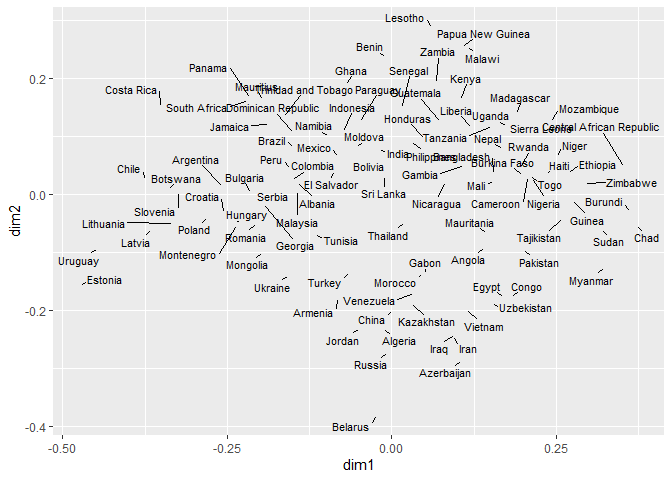

**Gráfica vía PAM**

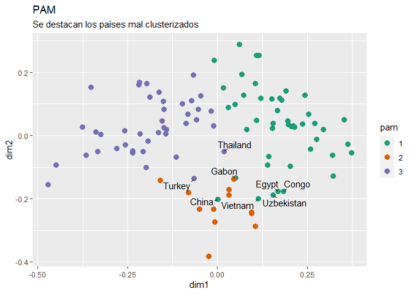

**Gráfica via AGNES**

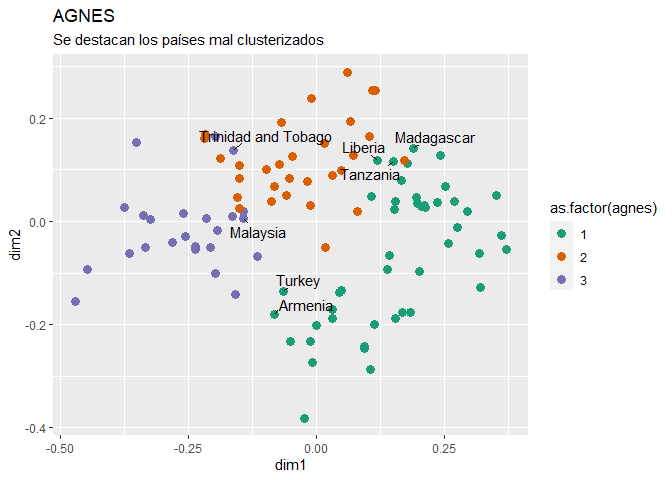

**Gráfica vía DIANA**

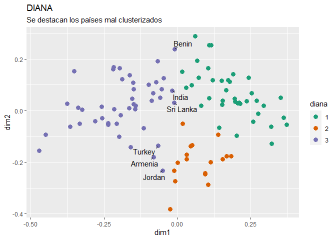

## Mapa mundial del conglomerado

En vista de las estrategias de partición realizadas y en función de este trabajo, se considera que por medio de diana se realiza una mejor división de los casos. Esto es debido a que las siluetas de los clusters y la representación gráfica nos demuestran una mejor organización de los casos.

Frente a ello, se elabora una representación de la reducción de dimensiones de las variables independientes por medio los clusters a nivel mundial:

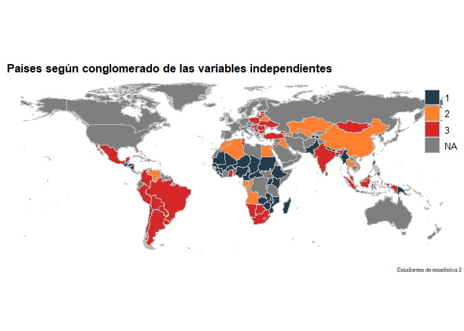

# 5. Conclusiones

En cuanto a un análisis factorial, nuestras variables se tratan principalmente de índices. Es decir, son variables latentes que ya se encuentran compuestas por indicadores. Debido a ello, no pueden ser agrupadas para formar nuevas variables latentes.

Finalmente, a través de un análisis de conglomerados, se hizo uso de varias técnicas para elaborar subconjuntos utilizando las variables independientes. Posteriormente, se escogió la agrupación realizada por medio del algoritmo DIANA, puesto que presento mejores resultados en función del presente trabajo. Finalmente, se hizo un gráfico con los tres clústeres que contenían nuestras variables independientes. Este gráfico nos ayudó a visualizar que, a nivel mundial, los conglomerados se encuentran concentrados en su mayoría de acuerdo a zonas geográficas. Es decir, entre ellas mantienen promedios más similares en materia de corrupción, derechos civiles o militarización.